# CRIMES IN BOSTON ANALYSIS

Arya Andhika

2019-07-22

## Take A Look the Data Type of “Crime in Boston” Data"

```r
str(boston)
```

```
## 'data.frame':    319073 obs. of  17 variables:
##  $ INCIDENT_NUMBER    : Factor w/ 282517 levels "142052550","I010370257-00",..: 282517 282516 282515 282514 282513 282512 282511 282510 282509 282508 ...
##  $ OFFENSE_CODE       : int  619 1402 3410 3114 3114 3820 724 3301 301 3301 ...
##  $ OFFENSE_CODE_GROUP : Factor w/ 67 levels "Aggravated Assault",..: 35 64 63 33 33 44 5 65 59 65 ...
##  $ OFFENSE_DESCRIPTION: Factor w/ 244 levels "A&B HANDS, FEET, ETC.  - MED. ATTENTION REQ.",..: 130 231 223 124 124 165 22 232 207 232 ...
##  $ DISTRICT           : Factor w/ 13 levels "","A1","A15",..: 9 7 10 10 6 7 5 5 8 7 ...
##  $ REPORTING_AREA     : int  808 347 151 272 421 398 330 584 177 364 ...
##  $ SHOOTING           : Factor w/ 2 levels "","Y": 1 1 1 1 1 1 1 1 1 1 ...
##  $ OCCURRED_ON_DATE   : Factor w/ 233229 levels "2015-06-15 00:00:00",..: 232988 230467 233216 233228 233226 233227 233229 233224 233225 233222 ...
##  $ YEAR               : int  2018 2018 2018 2018 2018 2018 2018 2018 2018 2018 ...
##  $ MONTH              : int  9 8 9 9 9 9 9 9 9 9 ...
##  $ DAY_OF_WEEK        : Factor w/ 7 levels "Friday","Monday",..: 4 6 2 2 2 2 2 2 2 2 ...
##  $ HOUR               : int  13 0 19 21 21 21 21 20 20 20 ...
##  $ UCR_PART           : Factor w/ 5 levels "","Other","Part One",..: 3 5 4 4 4 4 3 4 3 4 ...
##  $ STREET             : Factor w/ 4658 levels ""," ALBANY ST ",..: 2537 2075 786 3067 1242 4075 3100 2461 2742 2505 ...
##  $ Lat                : num  42.4 42.3 42.3 42.3 42.3 ...
##  $ Long               : num  -71.1 -71.1 -71.1 -71.1 -71.1 ...
##  $ Location           : Factor w/ 18194 levels "(-1.00000000, -1.00000000)",..: 15616 6832 13472 11292 2034 4673 6752 10012 10748 5513 ...
```

## Change the Data Type of “OCCURRED_ON_DATE”

```r
boston$INCIDENT_NUMBER <- as.character(boston$INCIDENT_NUMBER) #change the type into chr because unique
boston$OCCURRED_ON_DATE <- ymd_hms(boston$OCCURRED_ON_DATE,tz = "America/New_York") # change into date format
```

## Change the Data Type of “OFFENSE_CODE” and “REPORTING_AREA” into Factor (Repeated)

```r
boston$OFFENSE_CODE <- as.factor(boston$OFFENSE_CODE)
boston$REPORTING_AREA <- as.factor(boston$REPORTING_AREA)
```

## Take A Look the Summary of “Crime in Boston” Data"

```r
summary(boston)
```

```
##  INCIDENT_NUMBER     OFFENSE_CODE
##  Length:319073      3006   : 18783
##  Class :character   3115   : 18754
##  Mode  :character   3831   : 16323
##                     1402   : 15154
##                     802    : 14799
##                     3301   : 13099
##                     (Other):222161
##                        OFFENSE_CODE_GROUP
##  Motor Vehicle Accident Response: 37132
##  Larceny                        : 25935
##  Medical Assistance             : 23540
##  Investigate Person             : 18750
##  Other                          : 18075
##  Drug Violation                 : 16548
##  (Other)                        :179093
##                             OFFENSE_DESCRIPTION    DISTRICT
##  SICK/INJURED/MEDICAL - PERSON        : 18783   B2     :49945
##  INVESTIGATE PERSON                   : 18754   C11    :42530
##  M/V - LEAVING SCENE - PROPERTY DAMAGE: 16323   D4     :41915
##  VANDALISM                            : 15154   A1     :35717
##  ASSAULT SIMPLE - BATTERY             : 14791   B3     :35442
##  VERBAL DISPUTE                       : 13099   C6     :23460
##  (Other)                              :222169   (Other):90064
##  REPORTING_AREA   SHOOTING   OCCURRED_ON_DATE                   YEAR
##  111    :  2372    :318054   Min.   :2015-06-15 00:00:00   Min.   :2015
##  186    :  2016   Y:  1019   1st Qu.:2016-04-12 00:43:15   1st Qu.:2016
##  329    :  1878              Median :2017-01-28 03:11:00   Median :2017
##  117    :  1832              Mean   :2017-01-25 11:08:33   Mean   :2017
##  143    :  1775              3rd Qu.:2017-11-05 18:14:00   3rd Qu.:2017
##  (Other):288950              Max.   :2018-09-03 21:25:00   Max.   :2018
##  NA's   : 20250              NA's   :3
##      MONTH          DAY_OF_WEEK         HOUR             UCR_PART
##  Min.   : 1.00   Friday   :48495   Min.   : 0.00             :    90
##  1st Qu.: 4.00   Monday   :45679   1st Qu.: 9.00   Other     :  1232
##  Median : 7.00   Saturday :44818   Median :14.00   Part One  : 61629
##  Mean   : 6.61   Sunday   :40313   Mean   :13.12   Part Three:158553
##  3rd Qu.: 9.00   Thursday :46656   3rd Qu.:18.00   Part Two  : 97569
##  Max.   :12.00   Tuesday  :46383   Max.   :23.00
##                  Wednesday:46729
##             STREET            Lat             Long
##  WASHINGTON ST : 14194   Min.   :-1.00   Min.   :-71.18
##                : 10871   1st Qu.:42.30   1st Qu.:-71.10
##  BLUE HILL AVE :  7794   Median :42.33   Median :-71.08
##  BOYLSTON ST   :  7221   Mean   :42.21   Mean   :-70.91
##  DORCHESTER AVE:  5149   3rd Qu.:42.35   3rd Qu.:-71.06
##  TREMONT ST    :  4796   Max.   :42.40   Max.   : -1.00
##  (Other)       :269048   NA's   :19999   NA's   :19999
##                         Location
##  (0.00000000, 0.00000000)   : 19999
##  (42.34862382, -71.08277637):  1243
##  (42.36183857, -71.05976489):  1208
##  (42.28482577, -71.09137369):  1121
##  (42.32866284, -71.08563401):  1042
##  (42.25621592, -71.12401947):   898
##  (Other)                    :293562
```

## Clean Up the “NA’s” and “Blank” from Data

```r
boston <- boston[complete.cases(boston), ]
boston <- boston[!(boston$DISTRICT == ""), ]
```

## Change Month form numeric format into Abb. Month and Reorder Them

```r
boston$MONTH <- as.factor(month.abb[boston$MONTH])
boston$MONTH <- factor(boston$MONTH, levels=c("Jan", "Feb", "Mar", "Apr", "May", "Jun", "Jul", "Aug", "Sep", "Oct", "Nov", "Dec")) #reordering Level Month
```

## DAY_OF_WEEK stored in long format and not orederd

```r
boston$DAY_OF_WEEK <- wday(boston$OCCURRED_ON_DATE,
                           label = T,
                           abbr = T,
                           week_start = 1)
```

## Replace Missing Values in “SHOOTING” with “N”

```r
boston$SHOOTING <- as.factor(sub("^$", "N", boston$SHOOTING))
```

## Clean Up the Long and Lat Anomalies

```r
boston <- boston[!(boston$Lat == -1 & boston$Long == -1), ]
```

## Remove unused levels

```r
boston <- droplevels(boston)
```

##Simple Exploratory Data Analysis

Take a glimpse look at Crime Boston Data to find pattern or interesting findings

### By Year

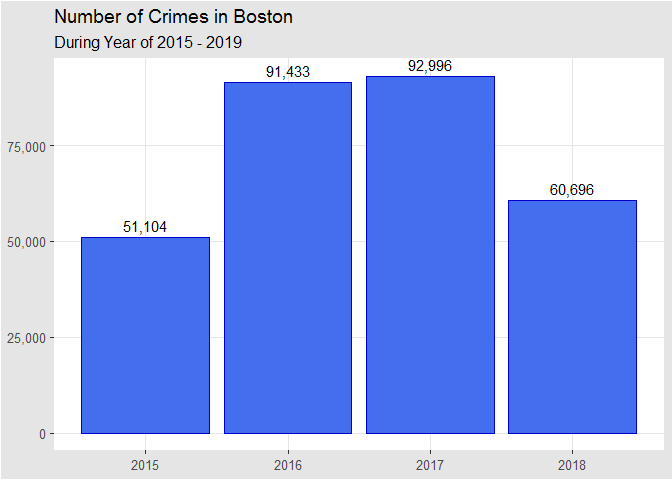

```r
ggplot(boston, aes(x = YEAR)) +
  geom_bar(fill = "royalblue2", col = "mediumblue") +
  theme_igray() +
  labs(x = NULL, y = NULL,
       title = "Number of Crimes in Boston",
       subtitle = "During Year of 2015 - 2019") +
  geom_text(aes(label=comma(..count..)),stat="count", position=position_dodge(0.9),vjust=-0.5) +
  scale_y_continuous(labels=comma)
```

We can see from the chart that Crimes in Boston Occured mostly in 2016 - 2017

### By Month

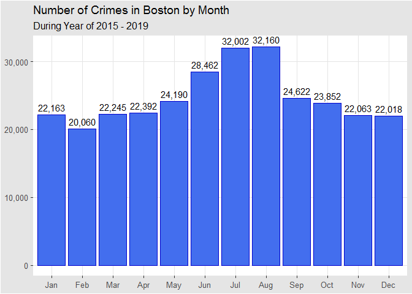

```r
ggplot(boston, aes(x = MONTH)) +
  geom_bar(fill = "royalblue2", col = "mediumblue") +
  theme_igray() +
  labs(x = NULL, y = NULL,
       title = "Number of Crimes in Boston by Month",
       subtitle = "During Year of 2015 - 2019") +
   geom_text(aes(label=comma(..count..)),stat="count", position=position_dodge(0.9),vjust=-0.5) +
   scale_y_continuous(labels=comma)
```

### By Season

Since there are 4 seasons in US, it will be interesting to see whether the seasons may affect the Crimes Rate

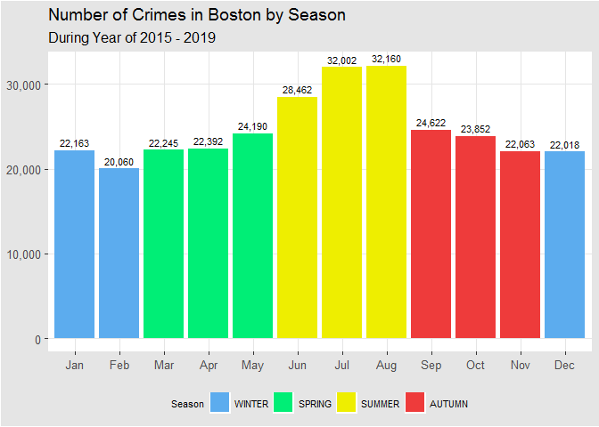

```r
# Create Function to divide 12 months into 4 seasons
season <- function(m){
                      if(m == "Mar" | m == "Apr" | m == "May"){
                        m <- "SPRING"
                      }else if(m == "Jun" | m == "Jul" | m == "Aug"){
                        m <- "SUMMER"
                      }else if(m == "Sep" | m == "Oct" | m == "Nov"){
                        m <- "AUTUMN"
                      }else{
                        m <- "WINTER"
                      }

                    }

# Apply it to Month and create new Column
boston$SEASON_OCCURED <- as.factor(sapply(boston$MONTH, season))

# Reorder it
boston$SEASON_OCCURED <- ordered(boston$SEASON_OCCURED,
                                                   levels = c("WINTER",
                                                              "SPRING",
                                                              "SUMMER",
                                                              "AUTUMN"))

ggplot(boston, aes(x = MONTH, fill = SEASON_OCCURED)) +
  geom_bar() +
  theme_igray() +
  labs(x = NULL, y = NULL,
       title = "Number of Crimes in Boston by Season",
       subtitle = "During Year of 2015 - 2019",
       fill = "Season") +
   geom_text(aes(label=comma(..count..)),stat="count", position=position_dodge(0.9), vjust=-0.5, size = 3) +
   scale_y_continuous(labels=comma) +
   scale_fill_manual(values = cbPalette[1:4]) +
   theme(legend.position = "bottom",
         legend.title = element_text(size = 8),
         legend.text = element_text(size = 8))
```

Summer is the season where Crimes in Boston Mostly Occured

### By Day of Week

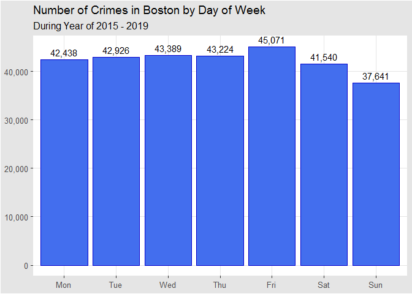

```r
ggplot(boston, aes(x = DAY_OF_WEEK)) +
  geom_bar(fill = "royalblue2", col = "mediumblue") +
  theme_igray() +
  labs(x = NULL, y = NULL,
       title = "Number of Crimes in Boston by Day of Week",
       subtitle = "During Year of 2015 - 2019") +
   geom_text(aes(label=comma(..count..)),stat="count", position=position_dodge(0.9),vjust=-0.5) +
   scale_y_continuous(labels=comma)
```

Crimes in Boston occur mostly in weekday, and peaked during Friday

### By Time

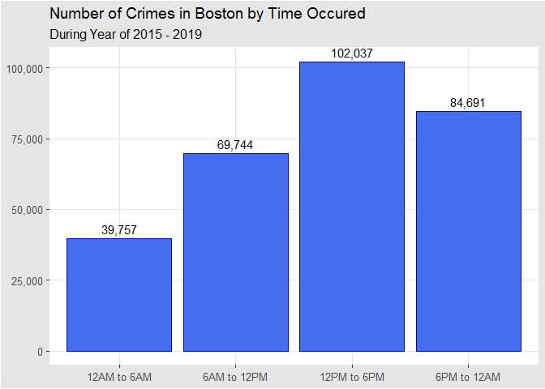

```r
event <- function(x){
                      if(x < 6){
                        x <- "12AM to 6AM"
                      }else if(x >= 6 & x < 12){
                        x <- "6AM to 12PM"
                      }else if(x >= 12 & x < 18){
                        x <- "12PM to 6PM"
                      }else{
                        x <- "6PM to 12AM"
                      }

                    }

boston$TIME_OCCURED <- as.factor(sapply(boston$HOUR, event))

boston$TIME_OCCURED <- ordered(boston$TIME_OCCURED,
                                                   levels = c("12AM to 6AM",
                                                              "6AM to 12PM",
                                                              "12PM to 6PM",
                                                              "6PM to 12AM"))

ggplot(boston, aes(x = TIME_OCCURED)) +
  geom_bar(fill = "royalblue2", col = "mediumblue") +
  theme_igray() +
  labs(x = NULL, y = NULL,
       title = "Number of Crimes in Boston by Time Occured",
       subtitle = "During Year of 2015 - 2019") +
   geom_text(aes(label=comma(..count..)),stat="count", position=position_dodge(0.9),vjust=-0.5) +
   scale_y_continuous(labels=comma)
```

Crimes happen mostly at 12PM - 6PM

### Correlation between Day of Week and the Time when Crimes Occur

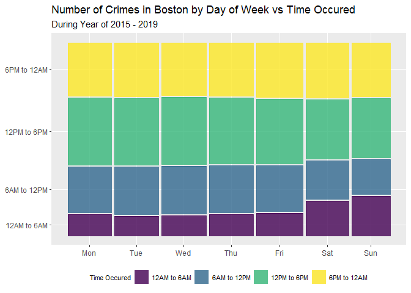

```r
ggplot(boston) +
  geom_mosaic(aes(x = product(DAY_OF_WEEK), fill=TIME_OCCURED)) +
  labs(x = NULL, y = NULL,
       title = "Number of Crimes in Boston by Day of Week vs Time Occured",
       subtitle = "During Year of 2015 - 2019",
       fill = "Time Occured") +
  theme(legend.position = "bottom",
         legend.title = element_text(size = 8),
         legend.text = element_text(size = 8))
```

On the weekday, Crimes in Boston happen during the same period. But interesting thing happen at weekend, there is some shifting of time occured, from 6AM-12PM into 12AM to 6AM.

## Take a look the most occured Offense Type, let’s say they occur more than 10k Cases

```r
boston10k <- as.data.frame(table(OFFENSE_TYPE = boston$OFFENSE_CODE_GROUP))
boston10k <- boston10k[boston10k$Freq >= 10000, ]
boston10k <- boston10k[order(boston10k$Freq, decreasing = T),]
boston10k
```

```
##                       OFFENSE_TYPE  Freq
## 44 Motor Vehicle Accident Response 30350
## 35                         Larceny 25032
## 41              Medical Assistance 22326
## 31              Investigate Person 17958
## 47                           Other 17009
## 62                  Simple Assault 14829
## 64                       Vandalism 14826
## 16                  Drug Violation 14371
## 65                 Verbal Disputes 12942
## 63                           Towed 10712
## 33            Investigate Property 10566
## 36      Larceny From Motor Vehicle 10226
```

```r
boston10k <- boston10k[boston10k$OFFENSE_TYPE != "Other", ]
```

We would like to take out Other since it may consists of few Offense Types

## Plot It Into Chart

[figure not shown]

```r
ggplot(boston10k, aes(x = reorder(OFFENSE_TYPE, Freq), y = Freq)) +
  geom_col(aes(fill=OFFENSE_TYPE)) +
  coord_flip() +
  theme_igray() +
  labs(x = NULL, y = NULL,
       title = "Top 10 Offense Type Numbers in Boston Crimes",
       subtitle = "During Year of 2015 - 2019") +
  scale_fill_brewer(palette = "Paired") +
  theme(legend.position = "none") +
  scale_y_continuous(labels=comma)
```

## Location Analysis

### By Districts

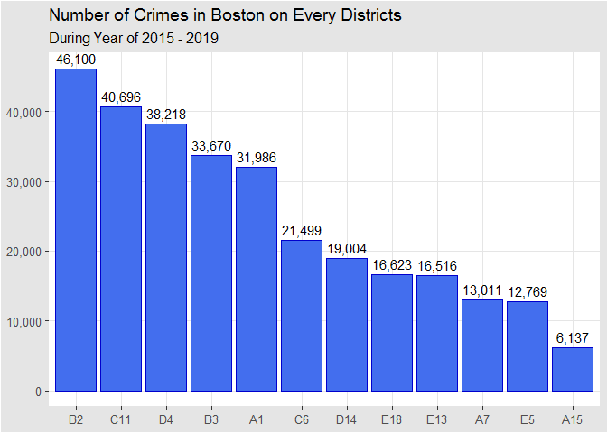

```r
newlev <- names(table(boston$DISTRICT))[order(table(boston$DISTRICT), decreasing = T)]
boston$DISTRICT <- factor(boston$DISTRICT, levels=newlev)

ggplot(boston, aes(x = DISTRICT)) +
  geom_bar(fill = "royalblue2", col = "mediumblue") +
  theme_igray() +
  labs(x = NULL, y = NULL,
       title = "Number of Crimes in Boston on Every Districts",
       subtitle = "During Year of 2015 - 2019") +
   geom_text(aes(label=comma(..count..)),stat="count", position=position_dodge(0.9),vjust=-0.5) +
   scale_y_continuous(labels=comma)
```

B2 is the District with most Cases, and A15 is the safest

### Districs vs Offense Type

We would like to see, the distribution of Top Numbers Offense Type (more than 10k cases) in every districts

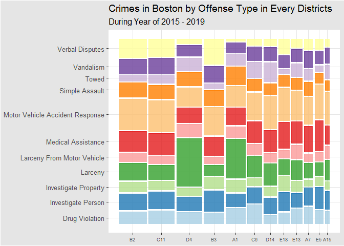

```r
bostonsort <- boston[which(boston$OFFENSE_CODE_GROUP %in% boston10k$OFFENSE_TYPE), ] # subset boston dataset which only contains Top Offense Type
bostonsort <- droplevels(bostonsort) # remove unused levels

sortlev <- names(table(bostonsort$DISTRICT))[order(table(bostonsort$DISTRICT), decreasing = T)] #sort form largest - smallest
bostonsort$DISTRICT <- factor(bostonsort$DISTRICT, levels=sortlev) # set as factor

ggplot(bostonsort) +
  geom_mosaic(aes(x = product(DISTRICT), fill=OFFENSE_CODE_GROUP)) +
  labs(x = NULL, y = NULL,
       title = "Crimes in Boston by Offense Type in Every Districts",
       subtitle = "During Year of 2015 - 2019",
       fill = "Time Occured") +
  theme_igray() +
  theme(legend.position = "none",
        axis.text.x = element_text(size = 7)) +
  scale_fill_brewer(palette = "Paired")
```

### Number of Crimes on Every Date

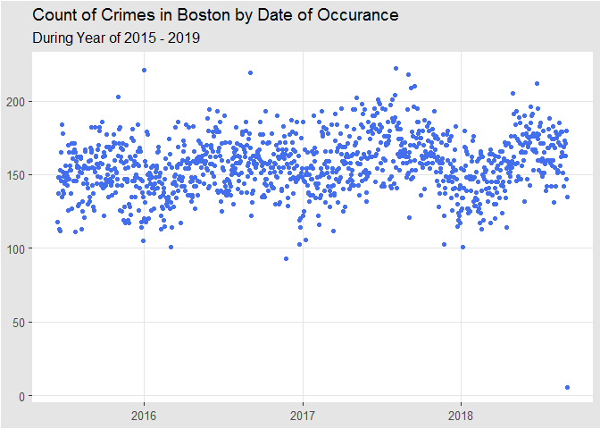

```r
#Change Format Date from POSIXct into Date
bostonsort$OCCURRED_ON_DATE <- as.Date(as.POSIXct(bostonsort$OCCURRED_ON_DATE,tz = "America/New_York"))


#count numbers of crimes by date of occurance
bostoncount <- bostonsort %>%
                  group_by(OCCURRED_ON_DATE) %>%
                  summarise(count = n()) %>%
                  ungroup()

ggplot(bostoncount, aes(x = OCCURRED_ON_DATE, y = count)) +
  geom_point(col = "royalblue2") +
  labs(x = NULL, y = NULL,
       title = "Count of Crimes in Boston by Date of Occurance",
       subtitle = "During Year of 2015 - 2019") +
  theme_igray()
```

Same like as shown by Month, the numbers of crimes mostly occured on mid year, and decline at the end of the year